# LAB 1

Exercise 1

Confusion matrices

```r
test_table
```

```
##
##       0   1   2   3   4   5   6   7   8   9
##   0  77   0   0   0   0   0   0   0   0   0
##   1   0  81   0   0   0   1   0   0   7   1
##   2   0   2  98   0   0   1   0   0   0   1
##   3   0   0   0 107   0   0   0   1   1   1
##   4   1   0   0   0  94   0   0   0   0   0
##   5   0   0   0   2   0  93   0   0   0   0
##   6   0   0   0   0   2   2  90   0   0   0
##   7   0   0   0   0   6   1   0 111   0   1
##   8   0   0   3   1   2   0   0   0  70   0
##   9   0   3   0   1   5   5   0   0   0  85
```

```r
train_table
```

```
##
##       0   1   2   3   4   5   6   7   8   9
##   0 202   0   0   0   1   0   0   0   0   1
##   1   0 179   1   0   3   0   2   3  10   3
##   2   0  11 190   0   0   0   0   0   0   0
##   3   0   0   0 185   0   1   0   0   2   5
##   4   0   0   0   0 159   0   0   0   0   2
##   5   0   0   0   1   0 171   0   0   0   0
##   6   0   0   0   0   0   0 190   0   2   0
##   7   0   1   1   1   7   1   0 178   0   3
##   8   0   1   0   0   1   0   0   1 188   3
##   9   0   3   0   1   4   8   0   0   2 183
```

Missclass Values

```r
missclass_test
```

```
## [1] 0.05329154
```

```r
missclass_train
```

```
## [1] 0.04500262
```

#Comment on the quality of predictions for different digits and on the overall prediction quality.

```
## [1]  520  431 1294
```

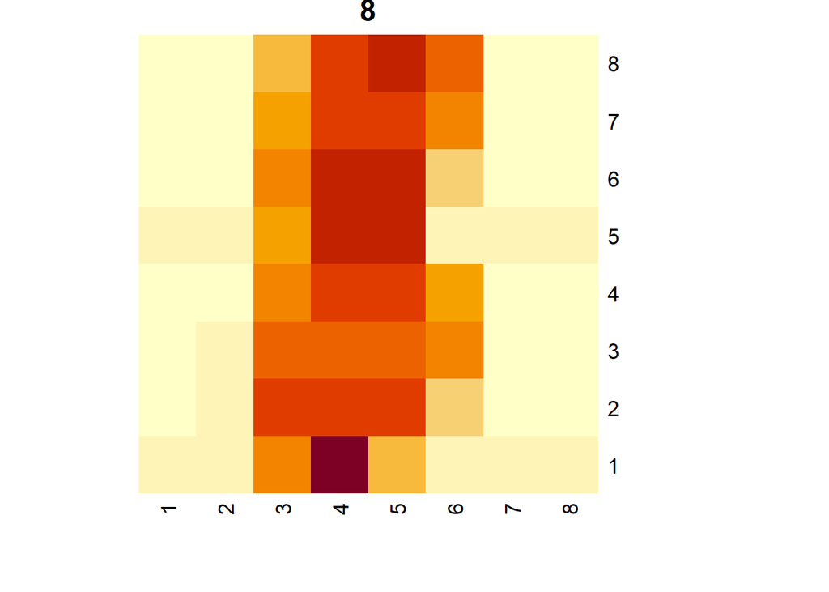

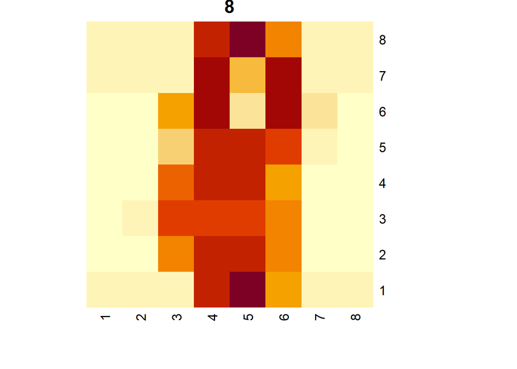

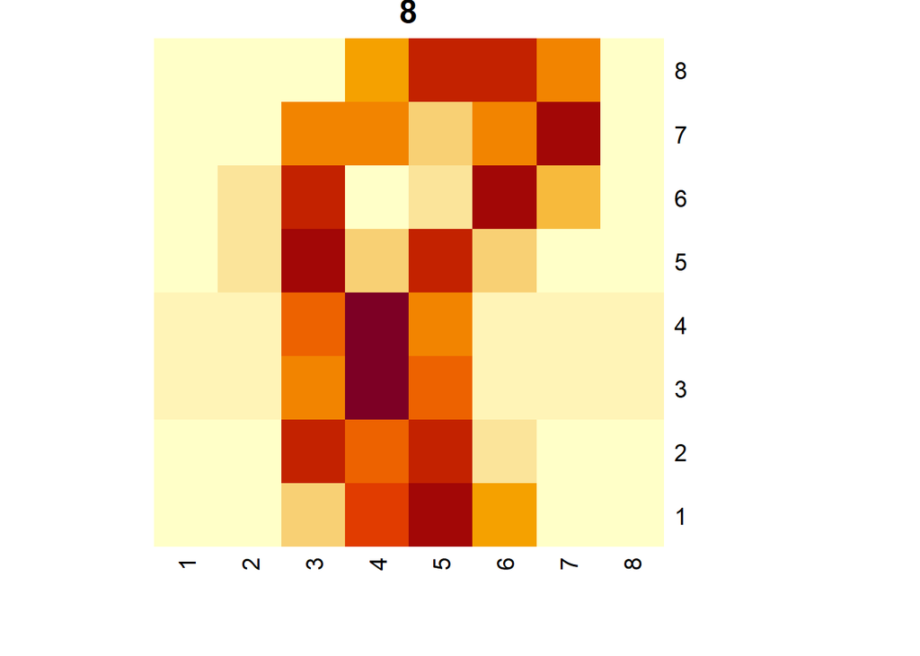

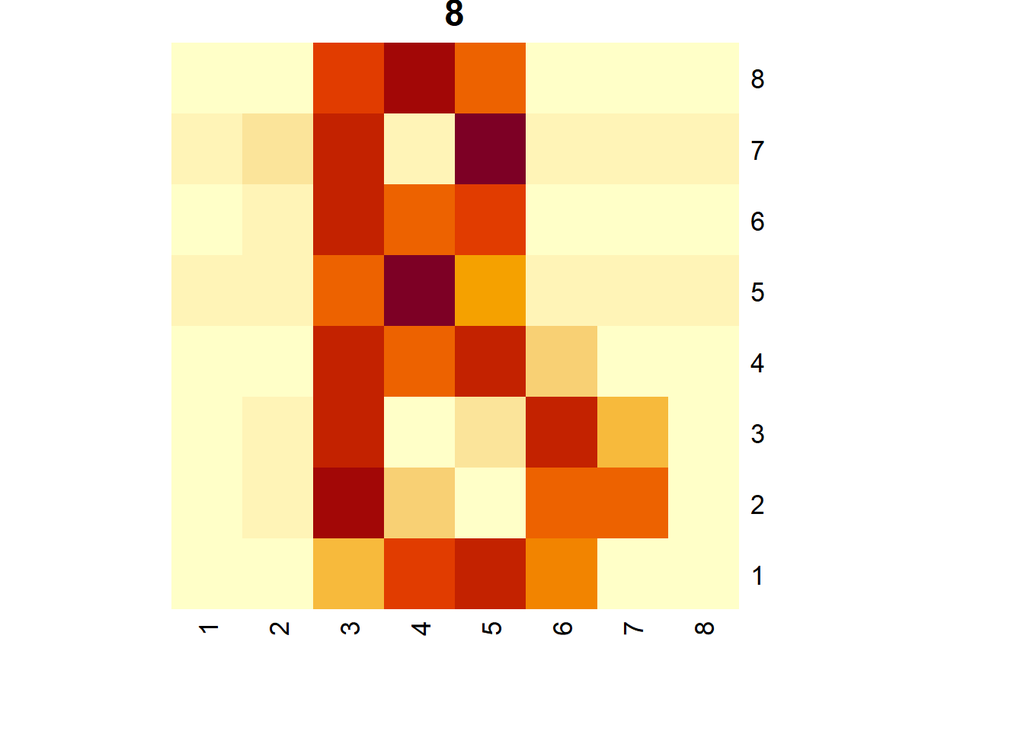

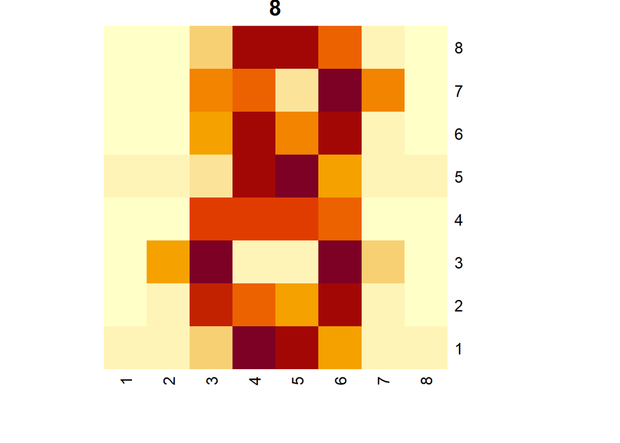

#comment on whether these cases seem to be hard or easy to recognize visually.

#The eights that were easy to classify are also very easy to see as eights. #The eights that were most difficult to spot are very difficult to see without knowing that they’re eights beforehand.

Exercise 4

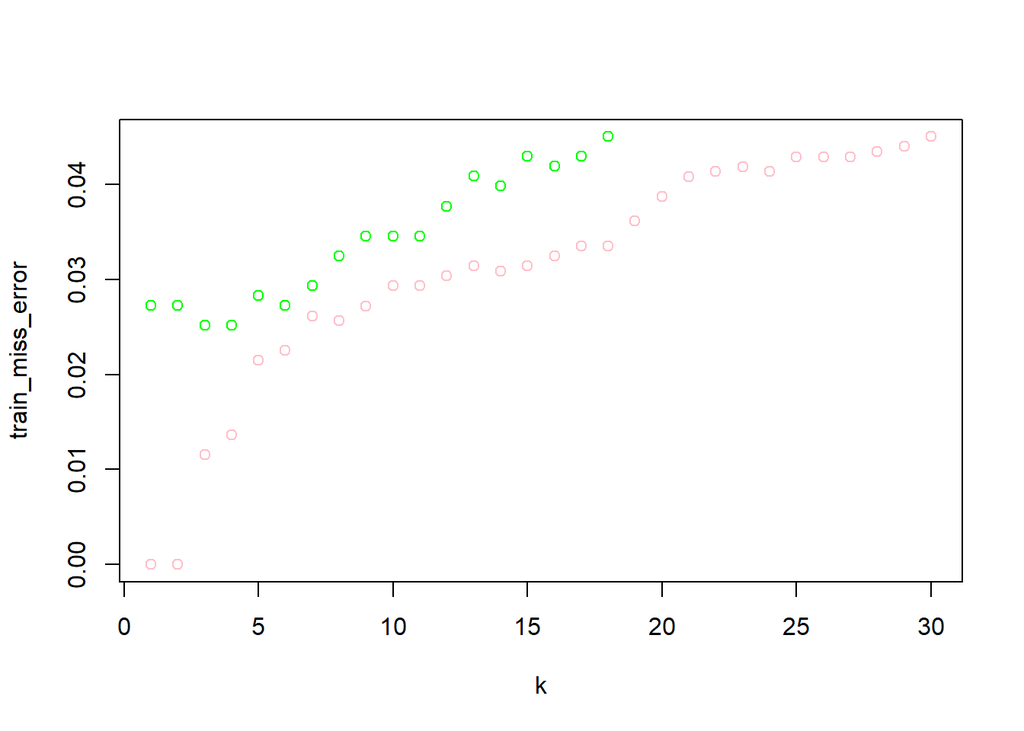

Missclass Values

```r
missclass_test
```

```
## [1] 0.02507837
```

```r
missclass_train
```

```
## [1] 0.01360544
```

```r
missclass_valid
```

```
## [1] 0.02513089
```

#How does the model complexity change when K increases and how does it affect the training and validation errors?

#We can see that train gives the lowest missclass error because it is the date we made the model from. #Both test and validation is slightly higher which is to be expected. #With the right k value computed with the validation data we get a test error which is just above 2.5% #Which results in a pretty high quality model.

Exercise 5

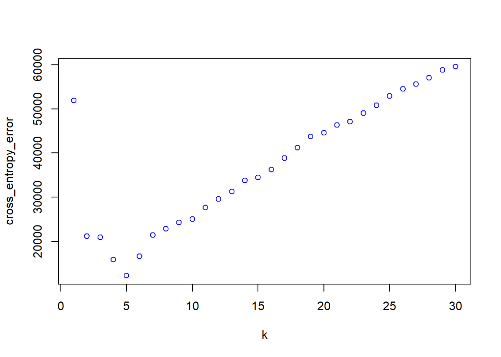

```
## [1] 5
```

#What is the optimal 𝐾𝐾 value here? Assuming that response has multinomial distribution, why might the cross-entropy be a more suitable choice of the error function than the missclassification error for this problem?

#This model might be more suitable because of lower complexity levels than missclass error. #The optimal K value here is K = 5.

Assigment 2

Excercise 2

```r
fit = lm(motor_UPDRS ~ ., data = train)
sum = summary(fit)
mean(sum$residuals^2)
```

```
## [1] 0.873147
```

```r
print(sum)
```

```
##
## Call:
## lm(formula = motor_UPDRS ~ ., data = train)
##
## Residuals:
##     Min      1Q  Median      3Q     Max
## -3.0162 -0.7340 -0.1084  0.7310  2.1892
##
## Coefficients:
##                 Estimate Std. Error t value Pr(>|t|)
## (Intercept)     0.006789   0.015790   0.430 0.667252
## Jitter...       0.180301   0.144277   1.250 0.211496
## Jitter.Abs.    -0.169795   0.040856  -4.156 3.32e-05 ***
## Jitter.RAP     -5.087728  18.186914  -0.280 0.779688
## Jitter.PPQ5    -0.071963   0.084712  -0.850 0.395659
## Jitter.DDP      5.068468  18.190294   0.279 0.780541
## Shimmer         0.590434   0.205314   2.876 0.004055 **
## Shimmer.dB.    -0.172730   0.139396  -1.239 0.215380
## Shimmer.APQ3   32.009848  77.023255   0.416 0.677738
## Shimmer.APQ5   -0.387249   0.113730  -3.405 0.000669 ***
## Shimmer.APQ11   0.310751   0.062288   4.989 6.37e-07 ***
## Shimmer.DDA   -32.325644  77.023042  -0.420 0.674739
## NHR            -0.186169   0.045766  -4.068 4.85e-05 ***
## HNR            -0.239653   0.036570  -6.553 6.45e-11 ***
## RPDE            0.004059   0.022615   0.179 0.857576
## DFA            -0.276898   0.019893 -13.919  < 2e-16 ***
## PPE             0.229100   0.033268   6.886 6.75e-12 ***
## ---
## Signif. codes:  0 '***' 0.001 '**' 0.01 '*' 0.05 '.' 0.1 ' ' 1
##
## Residual standard error: 0.9367 on 3508 degrees of freedom
## Multiple R-squared:  0.1212, Adjusted R-squared:  0.1172
## F-statistic: 30.24 on 16 and 3508 DF,  p-value: < 2.2e-16
```

Exercise3

Exercise 4

```
## [1] "Lambda: 1"
## [1] "TrainMSE: 0.873276884604699"
## [1] "TestMSE: 0.873276884604699"
## [1] "AIC: 2.71023988206812"
## [1] "Lambda: 100"
## [1] "TrainMSE: 0.879059997133881"
## [1] "TestMSE: 0.879059997133881"
## [1] "AIC: 2.7146141361159"
## [1] "Lambda: 1000"
## [1] "TrainMSE: 0.915627328917778"
## [1] "TestMSE: 0.915627328917778"
## [1] "AIC: 2.75293312438522"
```

#Which penalty parameter is most appropriate among the selected ones? Compute and compare the degrees of freedom of these models and make appropriate conclusions.

#We have read that to find the best aic value among mutiple aic values is the lowest. In our example it seems like lambda = 1 and lambda = 100 gives similar aic values which is hard to draw conclusions from. Lambda = 1 gives the lowest AIC value.

Assignment 3.

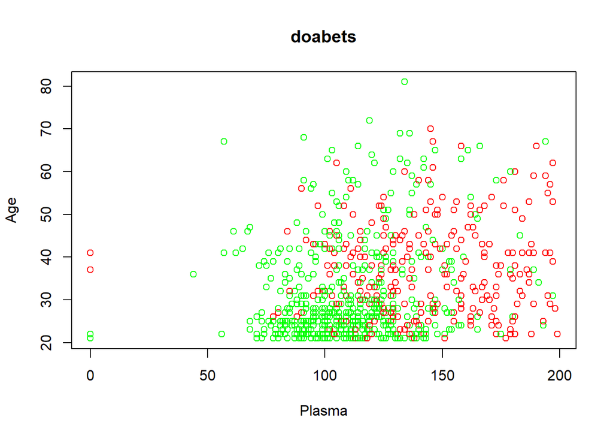

Exercise 2

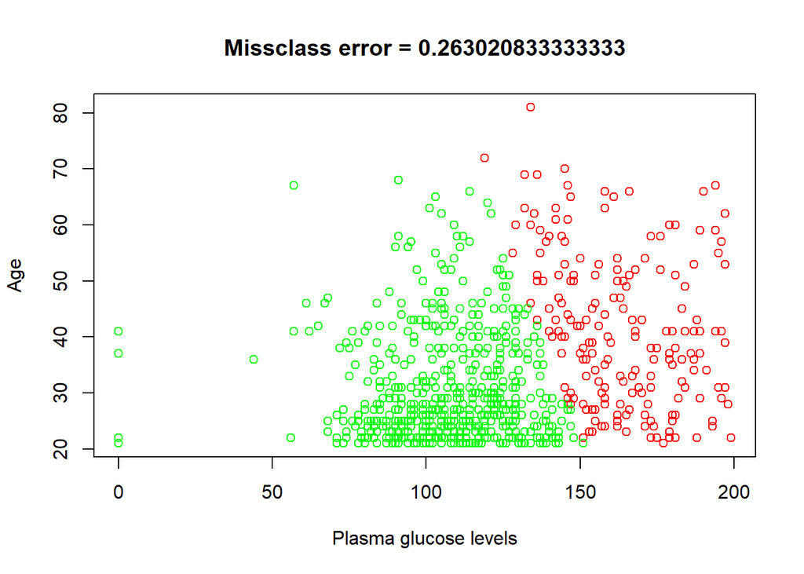

It seems to be an acceptable classification with about 1/4 error but not perfect There seems to be a division when you reach above 150 in plasma-glucose levels. But this threshold seems to lower as you age. An older person is more likely to have diabetes even with lower plasma-glucose levels.

Exercise 3

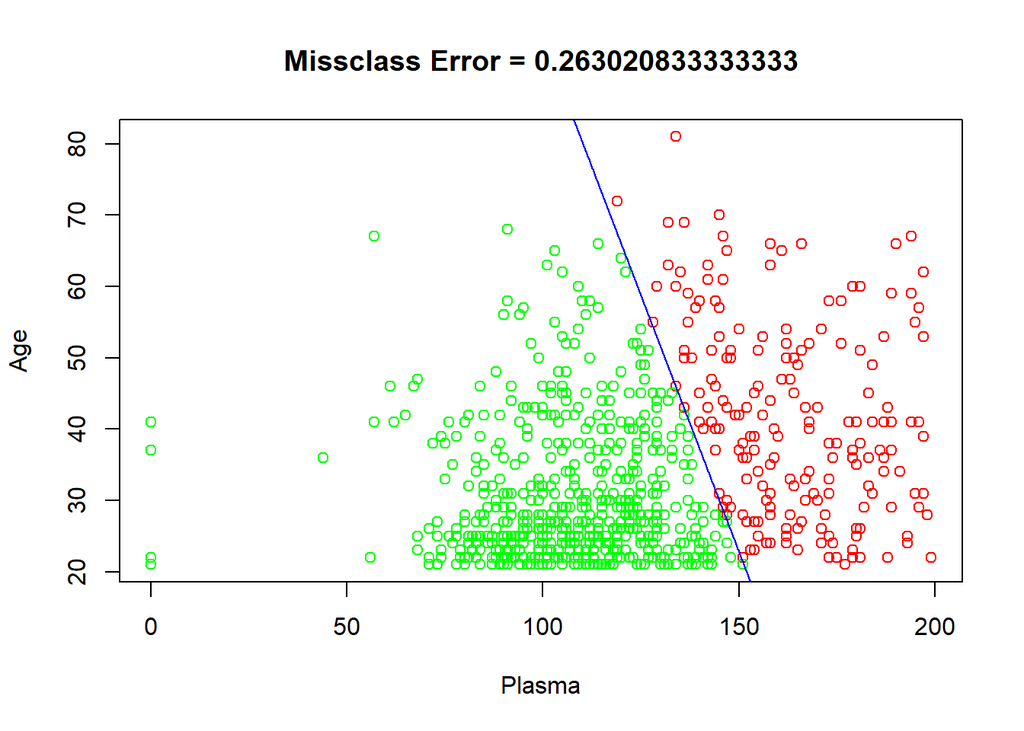

It catches the distribution very well

Exercise 4

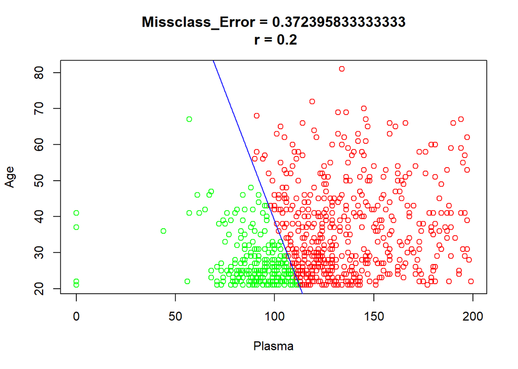

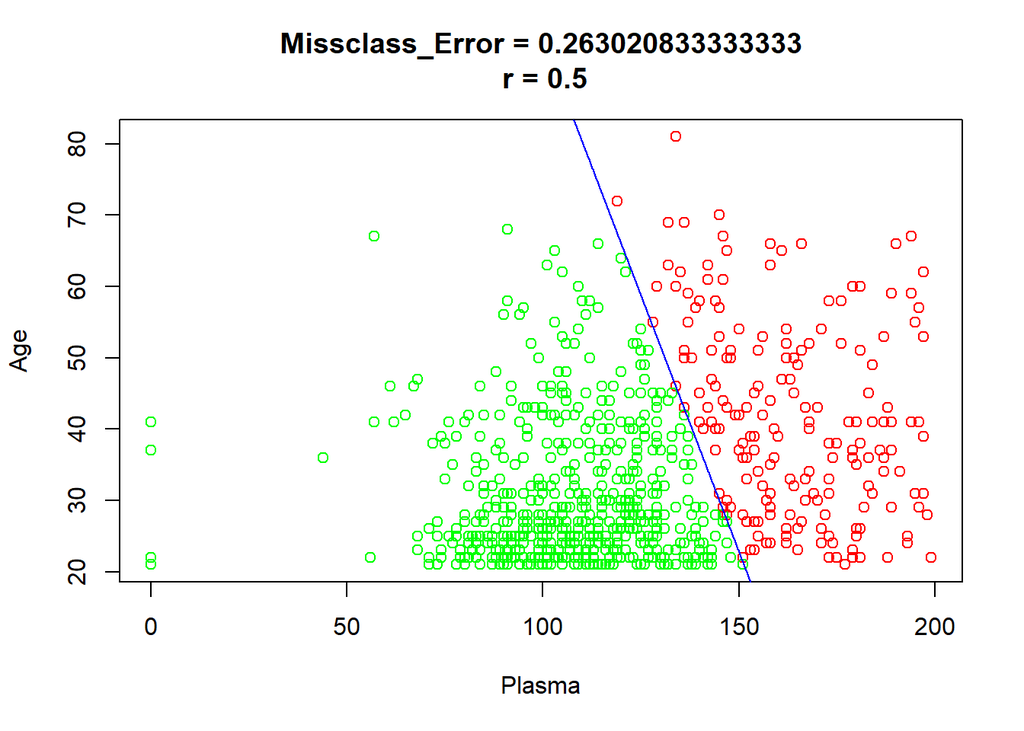

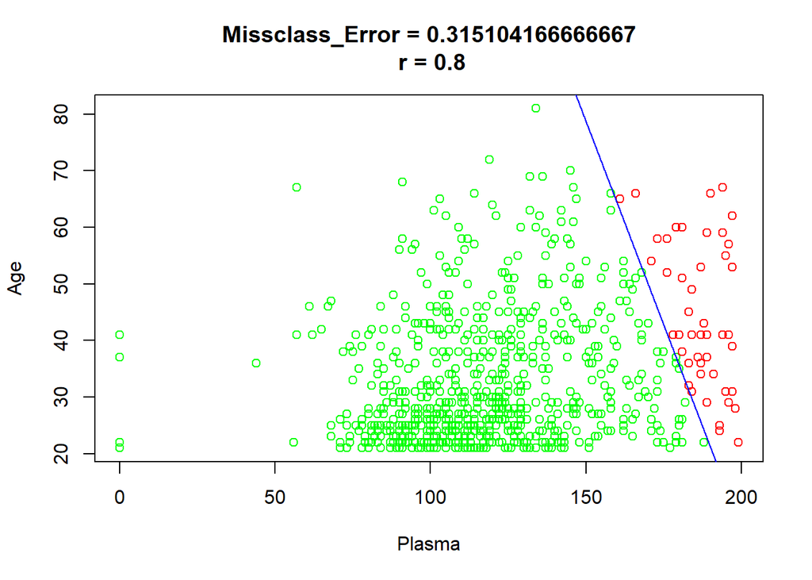

With r=.2 and r=.8, the missclassification error increased. r=.2 was clearly worse (37% error).

Exercise 5

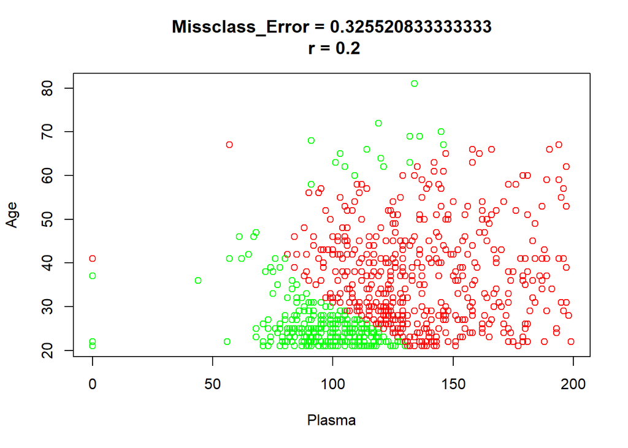

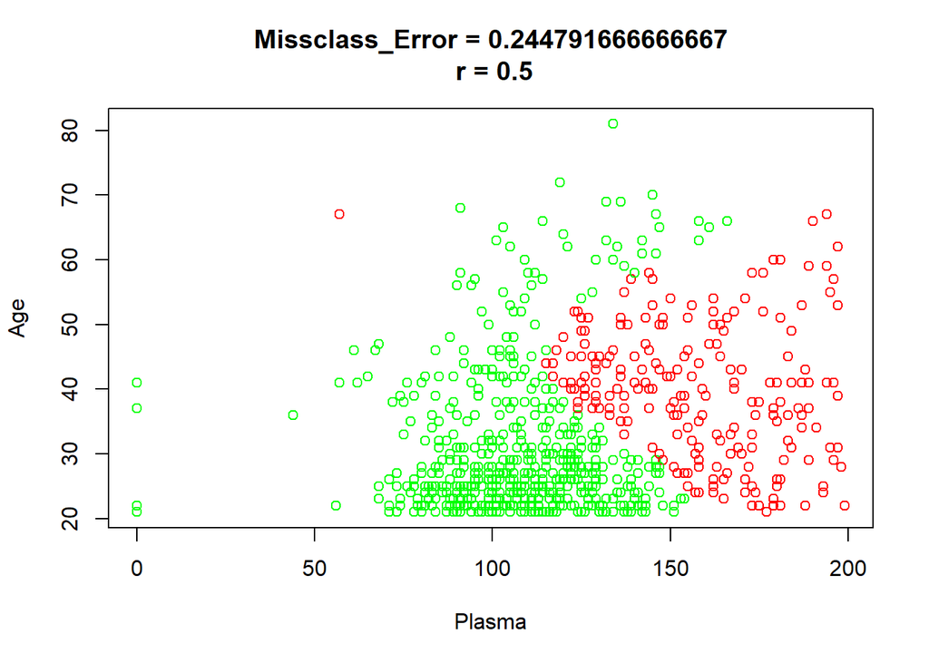

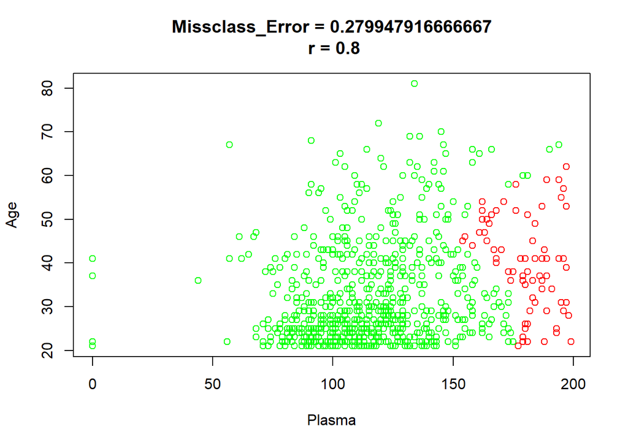

This model has a lower missclass error, so the quality of this model is slightly better than the previous one. The linearity of the model is however gone, since we’ve added non-linear variables. This causes the plotted colors to look more like a “slice”